# T04 — Classificação do dataset Iris

Bruno Sime

18 de outubro de 2026

# 1 Objetivo e dados

O objetivo é explorar as quatro medidas morfológicas do dataset **Iris**, aplicar Análise de Componentes Principais (PCA) e avaliar um classificador K-Nearest Neighbors (K-NN). O conjunto possui 150 plantas, 50 de cada uma das espécies *setosa*, *versicolor* e *virginica*, quatro variáveis em centímetros e nenhum valor ausente [1].

```
Dimensões: 150 linhas e 4 variáveis preditoras.
```

```
Valores ausentes: 0
```

# 2 Estatística descritiva

Como as medidas são contínuas, a moda é calculada sobre os valores observados com sua precisão original. Quando há empate, todas as modas são exibidas.

## 2.1 Resumo geral

| Variavel | Media | Desvio_padrao | Moda |
| --- | --- | --- | --- |
| Comprimento_sepala | 5,843 | 0,828 | 5 |
| Largura_sepala | 3,057 | 0,436 | 3 |
| Comprimento_petala | 3,758 | 1,765 | 1.4, 1.5 |
| Largura_petala | 1,199 | 0,762 | 0.2 |

## 2.2 Resumo por categoria

| Categoria | Variavel | Media | Desvio_padrao | Moda |
| --- | --- | --- | --- | --- |
| setosa | Comprimento_sepala | 5,006 | 0,352 | 5, 5.1 |
| setosa | Largura_sepala | 3,428 | 0,379 | 3.4 |
| setosa | Comprimento_petala | 1,462 | 0,174 | 1.4, 1.5 |
| setosa | Largura_petala | 0,246 | 0,105 | 0.2 |
| versicolor | Comprimento_sepala | 5,936 | 0,516 | 5.5, 5.6, 5.7 |
| versicolor | Largura_sepala | 2,770 | 0,314 | 3 |
| versicolor | Comprimento_petala | 4,260 | 0,470 | 4.5 |
| versicolor | Largura_petala | 1,326 | 0,198 | 1.3 |
| virginica | Comprimento_sepala | 6,588 | 0,636 | 6.3 |
| virginica | Largura_sepala | 2,974 | 0,322 | 3 |
| virginica | Comprimento_petala | 5,552 | 0,552 | 5.1 |
| virginica | Largura_petala | 2,026 | 0,275 | 1.8 |

## 2.3 Frequência das categorias

| Categoria | Frequencia | Percentual |
| --- | --- | --- |
| setosa | 50 | 33,3% |
| versicolor | 50 | 33,3% |
| virginica | 50 | 33,3% |

As classes são perfeitamente balanceadas: cada espécie representa um terço do conjunto. Assim, a acurácia é uma métrica interpretável e não é dominada por uma classe majoritária.

# 3 Relação entre comprimento e largura da sépala

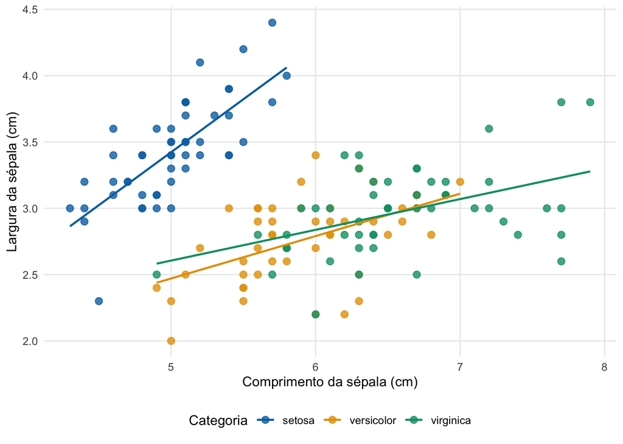

Comprimento e largura da sépala por categoria.

| Categoria | Correlacao_Pearson |
| --- | --- |
| setosa | 0,743 |
| versicolor | 0,526 |
| virginica | 0,457 |

Há sobreposição considerável entre *versicolor* e *virginica* no plano das sépalas. A *setosa* tende a ter sépalas mais curtas e relativamente mais largas. As correlações internas são positivas, mas a separação visual somente com essas duas variáveis é limitada.

# 4 Relação entre comprimento e largura da pétala

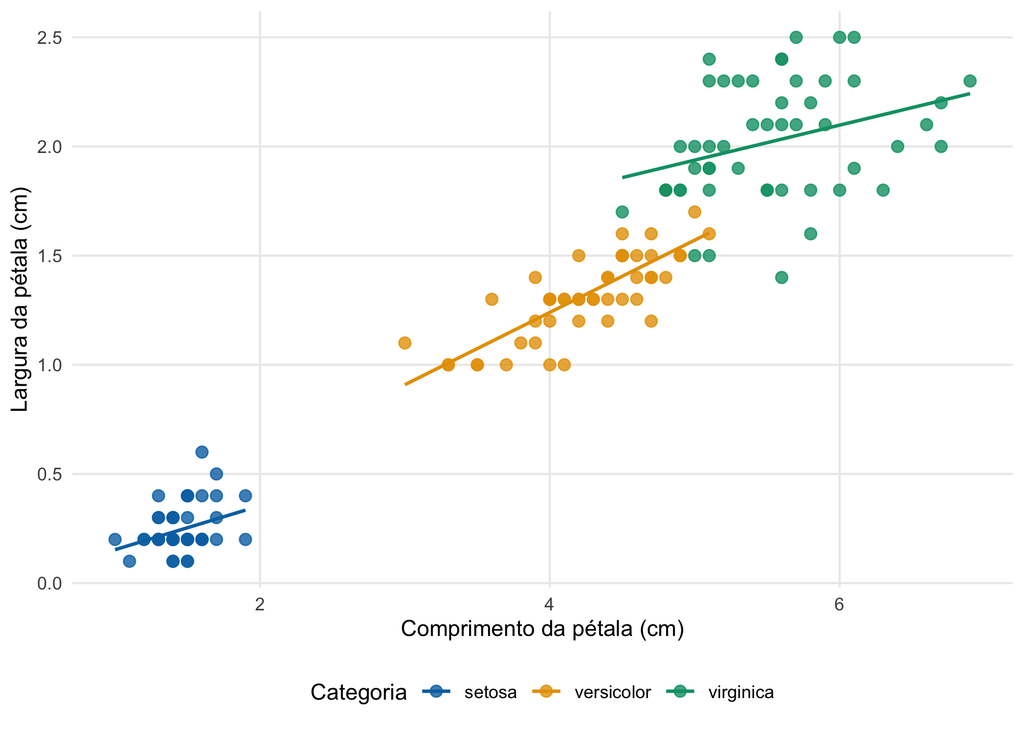

Comprimento e largura da pétala por categoria.

| Categoria | Correlacao_Pearson |
| --- | --- |
| setosa | 0,332 |
| versicolor | 0,787 |
| virginica | 0,322 |

As pétalas oferecem separação muito mais clara: *setosa* forma um grupo isolado, enquanto *versicolor* e *virginica* ainda apresentam uma pequena região de sobreposição. Em geral, pétalas mais compridas também são mais largas.

# 5 Distribuição conjunta nas quatro dimensões

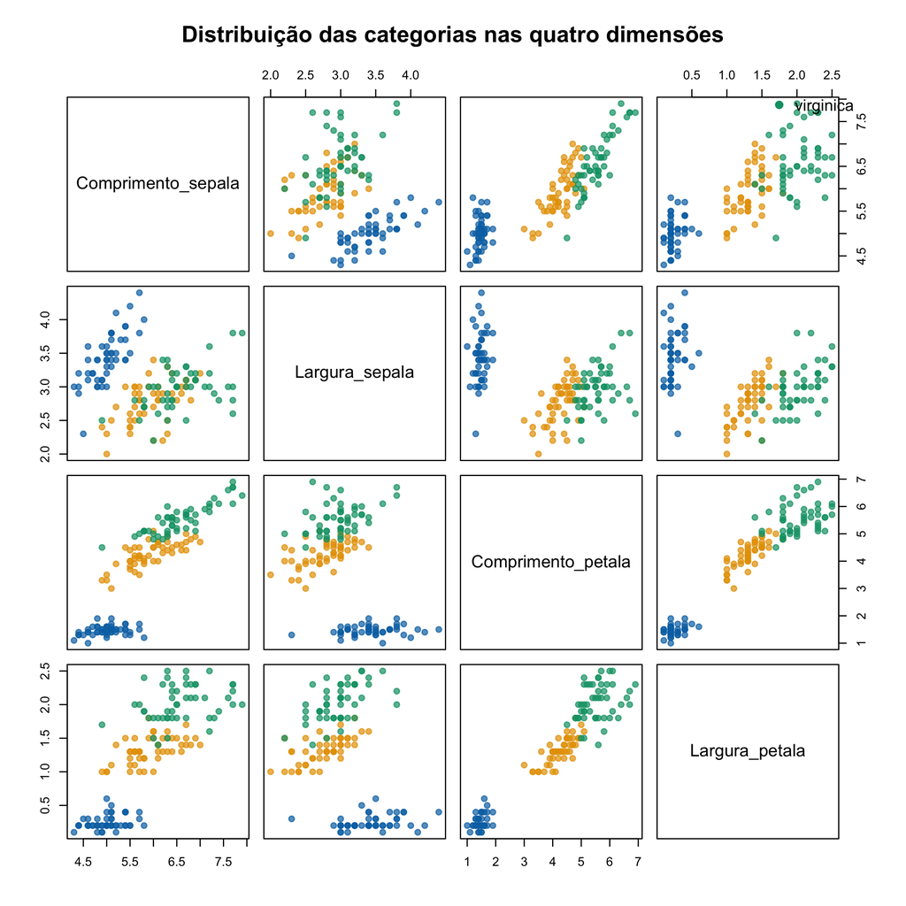

Matriz de dispersão das quatro variáveis.

Os pares envolvendo medidas de pétala são os mais discriminativos. Medidas de sépala, especialmente a largura, possuem maior sobreposição. Isso sugere que um classificador que combine as quatro dimensões pode aproveitar a separação das pétalas e usar as sépalas como informação complementar.